# PS1

## Ryan Westphal Problem Set 1

Load the data and set the bandwidth equal to the plug-in estimate. Below is printed the plug-in estimate for bandwidth

```r
mydata<-read.csv(file="bids1.csv", header=TRUE, sep=",") #load the bids data
bids = mydata[,1]
h <-bw.nrd0(bids) #set the bandwidth using direct plug-in
h #print the bandwidth
```

```
## [1] 0.2135111
```

**QUESTION 1** Estimate the density using an assumed normal distribution, a Gaussian Kernel and an Epanechnikov kernel, repectively.

```r
normal_mean<-mean(bids) #MLE estimate of normal distribution parameters are just sample mean
normal_sd<-sqrt(var(bids)) #and sample variance
x<-seq(min(bids),max(bids),length=512)
normreg<-dnorm(x, mean=normal_mean, sd=normal_sd) #create a density using these parameters
Kgauss = density(bids, bw=h, kernel='gaussian') #estimate the density using a Gaussian Kernel
Kepanech = density(bids, bw=h, kernel='epanech') #estimate the density using an Epanechnikov kernel
```

**QUESTION 2** Use a least-squares cross-validation to pick the bandwidth for the Epanechnikov kernel. Below is printed the bandwidth calculated using least-squares cross-validation.

```r
J<- function(h){ #Define the function we will be minimizing.  This is an approximation of the least squares
  fhat=Vectorize(function(x) density(bids,from=x,to=x,n=1,bw=h,kernel='epanech')$y)
  fhati=Vectorize(function(i) density(bids[-i],from=bids[i],to=bids[i],n=1,bw=h,kernel='epanech')$y)
  F=fhati(1:length(bids))
  return(integrate(function(x) fhat(x)^2,-Inf,Inf)$value-2*mean(F))
}
topt<- optimize(J,interval=c(.1,4)) #get the minimum of mean squared error
bwcv=topt$minimum #set bandwidth equal to this minimum
bwcv #print bandwidth
```

```
## [1] 0.3092193
```

```r
Kcv = density(bids, bw=bwcv, kernel='epanech') #estimate the density using an Epanechnikov kernel and this new bandwidth
```

**QUESTION 3** Plot the histogram of the bids along with the 4 estimated density functions

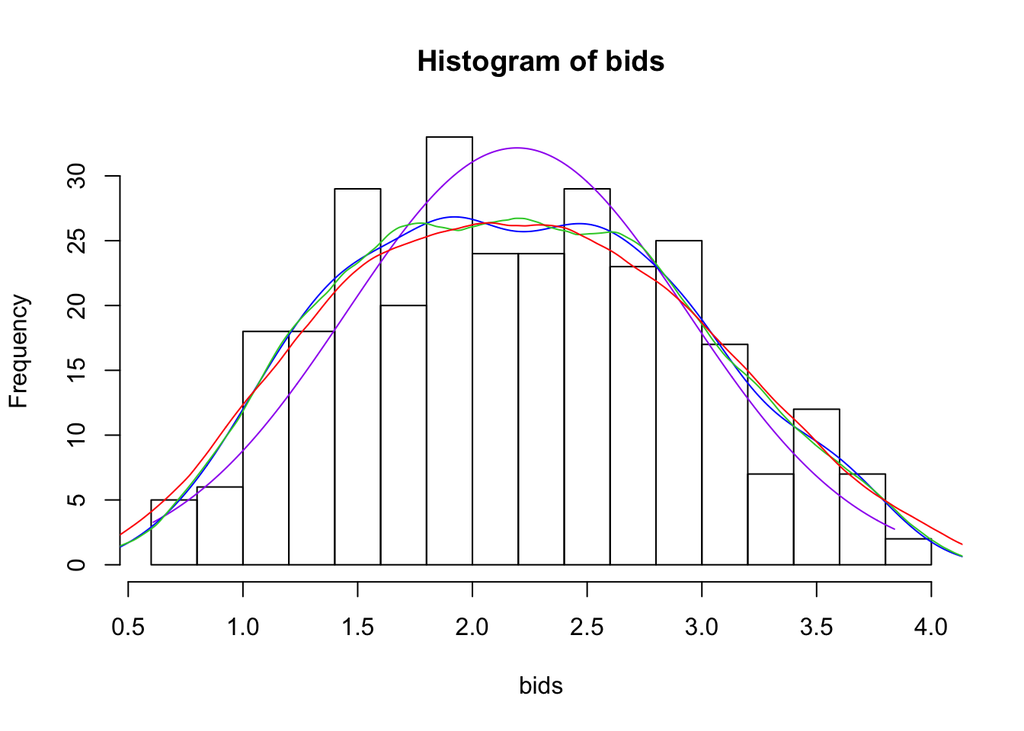

```r
gram<-hist(bids, breaks=14) #plot a histogram
normplot<-normreg*diff(gram$mids[1:2])*length(bids) #scale the normal distribution to fit the frequency data on the y-axis
Kgaussplot = Kgauss$y*diff(gram$mids[1:2])*length(bids) #scale the Gaussian kernel plot
Keplot = Kepanech$y*diff(gram$mids[1:2])*length(bids) #scale the Epanechnikov kernel plot
Kcvplot = Kcv$y*diff(gram$mids[1:2])*length(bids) #scale the Epanechnikov kernel plot with the cross-validated bandwidth
lines(x,normplot,col='purple') #plot the normal distribution
lines(Kgauss$x, Kgaussplot, col='blue') #plot the non-parametrically estimated density using gaussian kernel
lines(Kepanech$x, Keplot, col='limegreen') #plot the non-parametrically estimated density using Epanechnikov kernel with plug-in bw
lines(Kcv$x, Kcvplot, col='red') #plot the non-parametrically estimated density using Epanechnikov kernel with cv bw
```

**QUESTION 4** Use GPV and the estimated density of bids to recover the valuations from the observed bids

```r
Kcdf <- list(x=Kcv$x, y=cumsum(Kcv$y)) #Calculate the CDF from the estimated pdf
fPDF <- approxfun(Kcv$x, Kcv$y) #create a function to linearly interpolate between points of pdf
fCDF <- approxfun(Kcdf$x, Kcdf$y) #create a function to linearly interpolate between points of cdf
vals<-bids+fCDF(bids)/100/(2*fPDF(bids))
```

**Question 5** Estimate the density of valuations

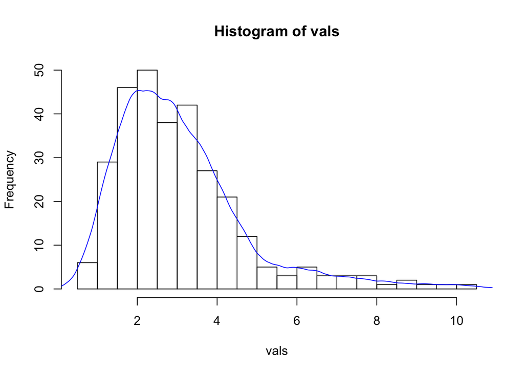

```r
gramv<-hist(vals, breaks=14) #plot the valuations
hvals <-bw.nrd0(vals) #get a bandwidth using the plug-in
Kepanechvals = density(vals, bw=hvals, kernel='epanech') #estimate the density using an Epanechnikov kernel
Kevalsplot = Kepanechvals$y*diff(gramv$mids[1:2])*length(vals)
lines(Kepanechvals$x, Kevalsplot, col='blue')
```

**Question 6** At a glance these valuations look like they were pulled from a log-normal distribution. If we try to fit this data with a log-normal we get a log-mean and log-sd of roughly 1 and 0.5. This looks like it fits the data pretty well and is fairly close to the nonparametrically estimated distribution.

```r
meanlog = mean(log(vals))
sdlog = sd(log(vals))
meanlog
```

```
## [1] 0.999239
```

```r
sdlog
```

```
## [1] 0.4939645
```

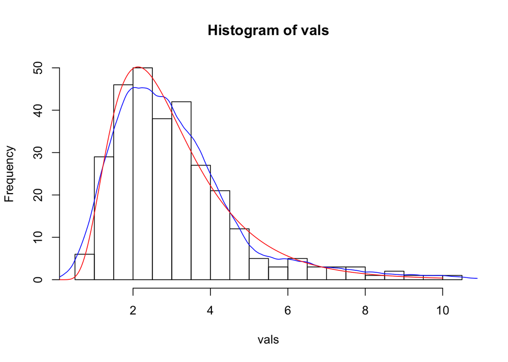

```r
hist(vals, breaks=14)
fitplotx <- seq(0, 10, 0.01)
fitploty <- dlnorm(fitplotx, meanlog, sdlog)*diff(gramv$mids[1:2])*length(vals)
lines(Kepanechvals$x, Kevalsplot, col='blue')
lines(fitplotx, fitploty, col='red')
```